```python
import marimo as mo
import pandas as pd
import numpy as np
import matplotlib.pyplot as plt
import seaborn as sns
import plotly.graph_objects as go
import plotly.express as px
from sklearn.model_selection import train_test_split
```

# Bank Marketing Dataset Ethical Analysis

## Introduction

- This notebook is assessment for Ethical Issues of AI.
- This notebook uses the Bank Marketing Dataset from the UCI Machine Learning Repository.
- The dataset contains information about direct marketing campaigns of a Portuguese banking institution.
- The goal is to predict whether a client will subscribe to a term deposit based on various features and understand the issues with respect to bias and fairness in AI models.

## Problem Statement

- To analyze the Bank Marketing Dataset for potential ethical issues, including bias and fairness in AI models.
- To identify any disparities in model performance across different demographic groups.

## About the data:

### Summary:

The data is related with direct marketing campaigns of a Portuguese banking institution. The marketing campaigns were based on phone calls. Often, more than one contact to the same client was required, in order to access if the product (bank term deposit) would be ('yes') or not ('no') subscribed.

There are four datasets:

1. bank-additional-full.csv with all examples (41188) and 20 inputs, ordered by date (from May 2008 to November 2010), very close to the data analyzed in [Moro et al., 2014]
2. bank-additional.csv with 10% of the examples (4119), randomly selected from 1), and 20 inputs.
3. bank-full.csv with all examples and 17 inputs, ordered by date (older version of this dataset with less inputs).
4. bank.csv with 10% of the examples and 17 inputs, randomly selected from 3 (older version of this dataset with less inputs). The smallest datasets are provided to test more computationally demanding machine learning algorithms (e.g., SVM).

The classification goal is to predict if the client will subscribe (yes/no) a term deposit (variable y).

### Variable Info:

Input variables:

1. `age` (numeric)
2. `job` : type of job (categorical: "admin.","unknown","unemployed","management","housemaid","entrepreneur","student", "blue-collar","self-employed","retired","technician","services")
3. `marital` : marital status (categorical: "married","divorced","single"; note: "divorced" means divorced or widowed)
4. `education` (categorical: "unknown","secondary","primary","tertiary")
5. `default`: has credit in default? (binary: "yes","no")
6. `balance`: average yearly balance, in euros (numeric)
7. `housing`: has housing loan? (binary: "yes","no")
8. `loan`: has personal loan? (binary: "yes","no")
9. `contact`: contact communication type (categorical: "unknown","telephone","cellular")
10. `day`: last contact day of the month (numeric)
11. `month`: last contact month of year (categorical: "jan", "feb", "mar", ..., "nov", "dec")
12. `duration`: last contact duration, in seconds (numeric)
13. `campaign`: number of contacts performed during this campaign and for this client (numeric, includes last contact)
14. `pdays`: number of days that passed by after the client was last contacted from a previous campaign (numeric, -1 means client was not previously contacted)
15. `previous`: number of contacts performed before this campaign and for this client (numeric)
16. `poutcome`: outcome of the previous marketing campaign (categorical: "unknown","other","failure","success")

Output variable (desired target): 17. `y` - has the client subscribed a term deposit? (binary: "yes","no")

## Data Loading & Preprocessing

```python
df = pd.read_csv("bank_marketing_data.csv")
df
```

|  | age | job | marital | education | default | balance | housing | loan | contact | day_of_week | month | duration | campaign | pdays | previous | poutcome | y |
| --- | --- | --- | --- | --- | --- | --- | --- | --- | --- | --- | --- | --- | --- | --- | --- | --- | --- |
| 0 | 58 | management | married | tertiary | no | 2143 | yes | no | NaN | 5 | may | 261 | 1 | -1 | 0 | NaN | no |
| 1 | 44 | technician | single | secondary | no | 29 | yes | no | NaN | 5 | may | 151 | 1 | -1 | 0 | NaN | no |
| 2 | 33 | entrepreneur | married | secondary | no | 2 | yes | yes | NaN | 5 | may | 76 | 1 | -1 | 0 | NaN | no |
| 3 | 47 | blue-collar | married | NaN | no | 1506 | yes | no | NaN | 5 | may | 92 | 1 | -1 | 0 | NaN | no |
| 4 | 33 | NaN | single | NaN | no | 1 | no | no | NaN | 5 | may | 198 | 1 | -1 | 0 | NaN | no |
| ... | ... | ... | ... | ... | ... | ... | ... | ... | ... | ... | ... | ... | ... | ... | ... | ... | ... |
| 45206 | 51 | technician | married | tertiary | no | 825 | no | no | cellular | 17 | nov | 977 | 3 | -1 | 0 | NaN | yes |
| 45207 | 71 | retired | divorced | primary | no | 1729 | no | no | cellular | 17 | nov | 456 | 2 | -1 | 0 | NaN | yes |
| 45208 | 72 | retired | married | secondary | no | 5715 | no | no | cellular | 17 | nov | 1127 | 5 | 184 | 3 | success | yes |
| 45209 | 57 | blue-collar | married | secondary | no | 668 | no | no | telephone | 17 | nov | 508 | 4 | -1 | 0 | NaN | no |
| 45210 | 37 | entrepreneur | married | secondary | no | 2971 | no | no | cellular | 17 | nov | 361 | 2 | 188 | 11 | other | no |

45211 rows × 17 columns

```python
mo.md(
    f"""### **Observation** The dataset has {len(df)} samples with {len(df.columns)} columns."""
)
```

**Observation** The dataset has 45211 samples with 17 columns.

```python
df.info(show_counts=True)
```

```
<class 'pandas.core.frame.DataFrame'>
RangeIndex: 45211 entries, 0 to 45210
Data columns (total 17 columns):
 #   Column       Non-Null Count  Dtype
---  ------       --------------  -----
 0   age          45211 non-null  int64
 1   job          44923 non-null  object
 2   marital      45211 non-null  object
 3   education    43354 non-null  object
 4   default      45211 non-null  object
 5   balance      45211 non-null  int64
 6   housing      45211 non-null  object
 7   loan         45211 non-null  object
 8   contact      32191 non-null  object
 9   day_of_week  45211 non-null  int64
 10  month        45211 non-null  object
 11  duration     45211 non-null  int64
 12  campaign     45211 non-null  int64
 13  pdays        45211 non-null  int64
 14  previous     45211 non-null  int64
 15  poutcome     8252 non-null   object
 16  y            45211 non-null  object
dtypes: int64(7), object(10)
memory usage: 5.9+ MB
```

```python
pd.DataFrame(df.isnull().sum()).T
```

|  | age | job | marital | education | default | balance | housing | loan | contact | day_of_week | month | duration | campaign | pdays | previous | poutcome | y |
| --- | --- | --- | --- | --- | --- | --- | --- | --- | --- | --- | --- | --- | --- | --- | --- | --- | --- |
| 0 | 0 | 288 | 0 | 1857 | 0 | 0 | 0 | 0 | 13020 | 0 | 0 | 0 | 0 | 0 | 0 | 36959 | 0 |

```python
mo.md(
    f"""
### **Observation** There are missing values in the dataset.
* `{", ".join(df.isnull().sum()[df.isnull().sum() != 0].index.tolist())}` columns have missing values.
"""
)
```

**Observation** There are missing values in the dataset.

- `job, education, contact, poutcome` columns have missing values.

```python
# Handling missing values via imputation
df[df.isnull().sum()[df.isnull().sum() != 0].index.tolist()]
```

|  | job | education | contact | poutcome |
| --- | --- | --- | --- | --- |
| 0 | management | tertiary | NaN | NaN |
| 1 | technician | secondary | NaN | NaN |
| 2 | entrepreneur | secondary | NaN | NaN |
| 3 | blue-collar | NaN | NaN | NaN |
| 4 | NaN | NaN | NaN | NaN |
| ... | ... | ... | ... | ... |
| 45206 | technician | tertiary | cellular | NaN |
| 45207 | retired | primary | cellular | NaN |
| 45208 | retired | secondary | cellular | success |
| 45209 | blue-collar | secondary | telephone | NaN |
| 45210 | entrepreneur | secondary | cellular | other |

45211 rows × 4 columns

### **Imputation Strategy**

- For `job` column we will mark missing values as 'unknown'.
- For `education` column we will mark missing values as 'unknown'.
- We will drop `contact` column as it has too many missing values.
- For `poutcome` column we will mark missing values as 'not-contacted'.

```python
def clean_data(df: pd.DataFrame) -> pd.DataFrame:
    df["job"] = df["job"].fillna("unknown")
    df["education"] = df["education"].fillna("unknown")
    df = df.drop(columns=["contact"])
    df["poutcome"] = df["poutcome"].fillna("not-contacted")
    return df


cleaned_df = df.pipe(clean_data)
cleaned_df
```

|  | age | job | marital | education | default | balance | housing | loan | day_of_week | month | duration | campaign | pdays | previous | poutcome | y |
| --- | --- | --- | --- | --- | --- | --- | --- | --- | --- | --- | --- | --- | --- | --- | --- | --- |
| 0 | 58 | management | married | tertiary | no | 2143 | yes | no | 5 | may | 261 | 1 | -1 | 0 | not-contacted | no |
| 1 | 44 | technician | single | secondary | no | 29 | yes | no | 5 | may | 151 | 1 | -1 | 0 | not-contacted | no |
| 2 | 33 | entrepreneur | married | secondary | no | 2 | yes | yes | 5 | may | 76 | 1 | -1 | 0 | not-contacted | no |
| 3 | 47 | blue-collar | married | unknown | no | 1506 | yes | no | 5 | may | 92 | 1 | -1 | 0 | not-contacted | no |
| 4 | 33 | unknown | single | unknown | no | 1 | no | no | 5 | may | 198 | 1 | -1 | 0 | not-contacted | no |
| ... | ... | ... | ... | ... | ... | ... | ... | ... | ... | ... | ... | ... | ... | ... | ... | ... |
| 45206 | 51 | technician | married | tertiary | no | 825 | no | no | 17 | nov | 977 | 3 | -1 | 0 | not-contacted | yes |
| 45207 | 71 | retired | divorced | primary | no | 1729 | no | no | 17 | nov | 456 | 2 | -1 | 0 | not-contacted | yes |
| 45208 | 72 | retired | married | secondary | no | 5715 | no | no | 17 | nov | 1127 | 5 | 184 | 3 | success | yes |
| 45209 | 57 | blue-collar | married | secondary | no | 668 | no | no | 17 | nov | 508 | 4 | -1 | 0 | not-contacted | no |
| 45210 | 37 | entrepreneur | married | secondary | no | 2971 | no | no | 17 | nov | 361 | 2 | 188 | 11 | other | no |

45211 rows × 16 columns

```python
pd.DataFrame(cleaned_df.isnull().sum()).T
```

|  | age | job | marital | education | default | balance | housing | loan | day_of_week | month | duration | campaign | pdays | previous | poutcome | y |
| --- | --- | --- | --- | --- | --- | --- | --- | --- | --- | --- | --- | --- | --- | --- | --- | --- |
| 0 | 0 | 0 | 0 | 0 | 0 | 0 | 0 | 0 | 0 | 0 | 0 | 0 | 0 | 0 | 0 | 0 |

```python
mo.md(
    f"""### **Observation** After cleaning, the dataset has {len(cleaned_df)} samples with {len(cleaned_df.columns)} columns and no missing values."""
)
```

**Observation** After cleaning, the dataset has 45211 samples with 16 columns and no missing values.

## Exploratory Data Analysis (EDA)

```python
cleaned_df.columns
```

```
Index(['age', 'job', 'marital', 'education', 'default', 'balance', 'housing',
       'loan', 'day_of_week', 'month', 'duration', 'campaign', 'pdays',
       'previous', 'poutcome', 'y'],
      dtype='object')
```

```python
features = cleaned_df.drop(columns="y").columns.tolist()
mo.ui.table(features, label="## Features in the Dataset")
```

[output not shown]

```python
mo.ui.table(
    cleaned_df[features].describe(include=[np.number]),
    label="## Statistical Summary of Numerical Features",
)
```

[output not shown]

```python
mo.ui.table(
    cleaned_df[features].describe(include=["object"]),
    label="## Statistical Summary of Categorical Features",
)
```

[output not shown]

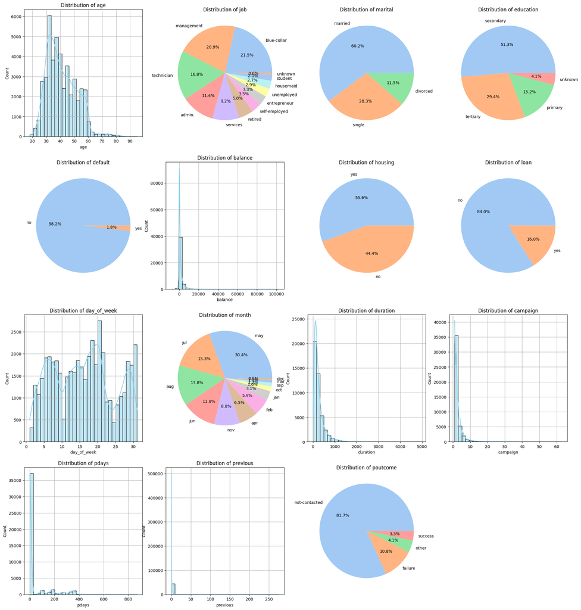

[figure not shown]

```python
plt.figure(figsize=(24, 26))
for f in features:
    if cleaned_df[f].dtype == "object":
        plt.subplot(4, 4, features.index(f) + 1)
        plt.pie(
            cleaned_df[f].value_counts(),
            autopct="%1.1f%%",
            labels=cleaned_df[f].value_counts().index,
            colors=sns.color_palette("pastel"),
        )
        plt.title(f"Distribution of {f}")
        plt.xticks(rotation=45)
        plt.grid()
    else:
        plt.subplot(4, 4, features.index(f) + 1)
        sns.histplot(cleaned_df[f], bins=30, kde=True, color="skyblue")
        plt.title(f"Distribution of {f}")
        plt.grid()
plt.gcf()
```